# 06 Model Complexity and Generalization in Supervised Learning

Our goal in supervised learning is to use sample data to detect patterns in the target population. There will always be a difference between our training data and the population we want to model. Training data will always overfit because we are using it to fit a model in the first place.

Let’s embark on this exploration by understanding the intricate dance between model complexity and generalization, and how this interplay impacts overfitting, underfitting, and the legendary bias-variance tradeoff.  
* Overfitting is when our model fits our the training data extremely well. As a result, an overfit model will perform poorly when predicting new unseen data. Here the model essentially memorizes the training data rather than generalize from it. High Variance often leads to overfitting.  
* Underfitting where the model doesnt reach its full predictive capabilities from our data. Its too simplistic to capture the underlying patterns in the data. Models with high bias are prone to underfitting. * A model with high bias makes strong assumptions about the underlying data distribution and may not be able to represent the true relationship between the features and the target variable.  
* Variance, on the other hand, refers to the model’s sensitivity to small fluctuations in the training data.

Data source: https://www.kaggle.com/competitions/house-prices-advanced-regression-techniques

# Prepare the workspace

```r
options(
  digits = 5, # print out only 5 significant digits
  scipen = 999, # the larger the number the more r avoids scientific notation
  warn = -1 # suppresses warnings
)
rm( # removing any artifacts from workspace so that there are not any interference in our code
  list = ls()
)
library(magrittr) # for piping
```

# Load our data

```r
set.seed(
  seed = 823
)
M <- readr::read_csv(
  file = "/Users/thienpham/Data Mining/data/prepared_house_prices.csv",
  col_types = "cnnnnnnnnnnnnnnnnnnnnnnnnnnnnnnnnnnnnnnnnnnnnnnnnnnnnnnnnnnnnnnnnnnnnnnnnnnnnnnnccn",
  name_repair = janitor::make_clean_names
) %>%
  # only relevant for this dataset (if we know target var value = train, if not = test)
  dplyr::filter(train_test == "Train") %>%
  dplyr::mutate(
    train_test = "Test"
  ) %>%
  as.data.frame()
```

# Model Complexity

Model complexity is determined by several factors, among which include:

1. **Mathematical Structure of the Model**: Complex mathematical structures can identify nuanced patterns but may also fit noise in the data, leading to overfitting. (types of model structures, regression, trees, …)
- more rows/more data means more complex of a model we can have without overfitting
2. **Number of Predictor Variables**: Introducing more predictor variables can increase the model’s complexity. With greater complexity, the model has increased flexibility but also a higher propensity to overfit. The more predictor variables you have the more prone to overfitting you are.
3. **Number of Parameters**: The more parameters a model has, the more “knobs” or “dials” there are to adjust during training, which can again lead to overfitting if not managed correctly.

# Model Generalization

Generalization refers to how well a model trained on one dataset can predict outcomes on an entirely different dataset. If a model generalizes well, it has likely captured the underlying patterns in the data without fitting to the noise. However, if it generalizes poorly, it’s likely overfitting or underfitting.

# Overfitting and Underfitting

- **Overfitting**: Occurs when a model learns the training data too closely, including its noise and outliers. It will often show near-perfect performance on the training data but poor performance on new, unseen data.
- **Underfitting**: Occurs when a model doesn’t capture the underlying pattern of the data, usually because the model is too simple. It performs poorly on both the training data and new data.

It is better to underfit than to overfit.

- With underfitting, we typically know how the model will perform in the future.
- With overfitting we expect gold and get manure. It can be a serious problem professionally when a model does not meet expectations.

Remember, overfitting and underfitting are not binary conditions but fall on a continuum.

# Example: Overfitting with Polynomial Regression - Extreme Overfitting

Here we overfit on purpose.

We reduce the training data to just the first occurrence of unique predictor values, then fit the highest degree polynomial regression model that R will allow.

```r
# Taking the first occurrence of unique values in the predictor variable lot_area
j <- 10
match_M <- match(
  x = unique(
    x = round(M$lot_area)
  ),
  table = round(M$lot_area)
)[1:(j+1)]

# Then minimize to just a few data points
M$train_test[match_M] <- "Train"

# Then go through and build a polynomial of degree 1-10
list_poly <- lapply(
  X = 1:j,
  FUN = function(degree) lm(
    formula = box_cox_sale_price ~ poly(lot_area,degree),
    data = M[match_M,c("box_cox_sale_price","lot_area")]
  )
)

# Then fit model and check statistics
M_predict <- sapply(
  X = list_poly,
  FUN = predict,
  newdata = M
) %>%
  as.data.frame()
colnames(M_predict) <- stringr::str_pad(
  string = 1:j,
  width = 2,
  pad = "0"
)
M_predict <- M_predict %>%
  dplyr::mutate(
    box_cox_sale_price = M$box_cox_sale_price,
    lot_area = M$lot_area,
    train_test = M$train_test
  ) %>%
  tidyr::gather(
    key = "degree",
    value = "prediction",
    -box_cox_sale_price,-train_test,-lot_area
  ) %>%
  dplyr::mutate(
    residual = prediction - box_cox_sale_price
  )
M_predict %>%
  dplyr::group_by(train_test,degree) %>%
  dplyr::summarise(
    mean_squared_error = mean((residual)^2)
  ) %>%
  tidyr::spread(
    key = train_test,
    value = mean_squared_error
  )
```

```
## # A tibble: 10 × 3
##    degree     Test    Train
##    <chr>     <dbl>    <dbl>
##  1 01     1.96e- 1 7.76e- 2
##  2 02     8.51e- 1 6.27e- 2
##  3 03     5.19e+ 0 6.05e- 2
##  4 04     9.61e+ 2 4.77e- 2
##  5 05     2.35e+ 4 4.50e- 2
##  6 06     1.16e+ 7 2.61e- 2
##  7 07     3.16e+ 8 2.42e- 2
##  8 08     7.32e+11 1.12e- 2
##  9 09     1.70e+13 1.07e- 2
## 10 10     3.28e+18 3.56e-25
```

Here if we called the test sample the validation sample, it would still be the same result since it is unseen data, just different names for different purposes.

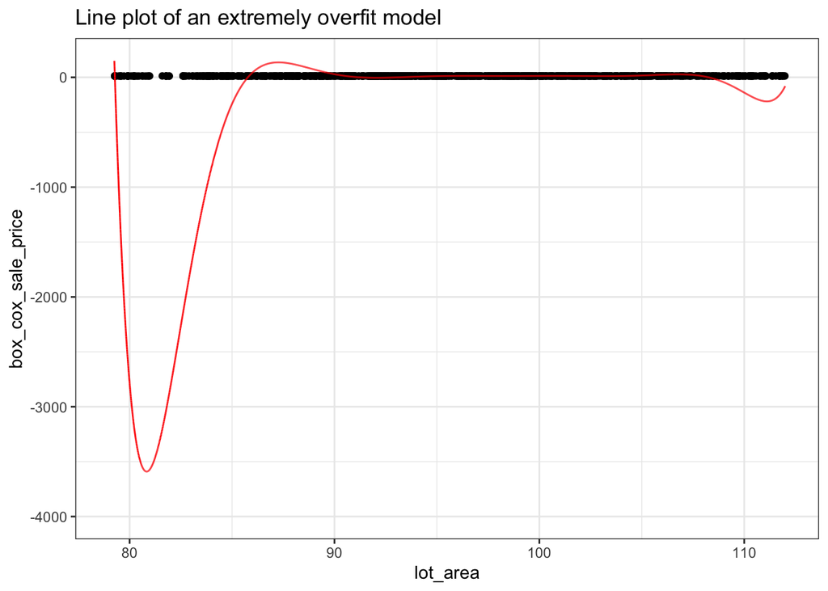

```r
# Here we visualize the degree 10 polynomial
M_polynomial <- data.frame(
  lot_area = seq(
    from = min(M$lot_area),
    to = max(M$lot_area[M$train_test == "Train"]),
    length = 1e6
  )
)
M_polynomial$predict <- predict(
  object = list_poly[[10]],
  newdata = M_polynomial
)
library(ggplot2)
ggplot(M_predict %>% dplyr::filter(degree == "10")) +
  aes(x = lot_area,y = box_cox_sale_price) +
  geom_point() +
  geom_line(data = M_polynomial,mapping = aes(x = lot_area,y = predict),color = "red") +
  xlim(79,112) +
  ylim(-4000,150) +
  theme_bw() +
  labs(
    title = "Line plot of an extremely overfit model"
  )
```

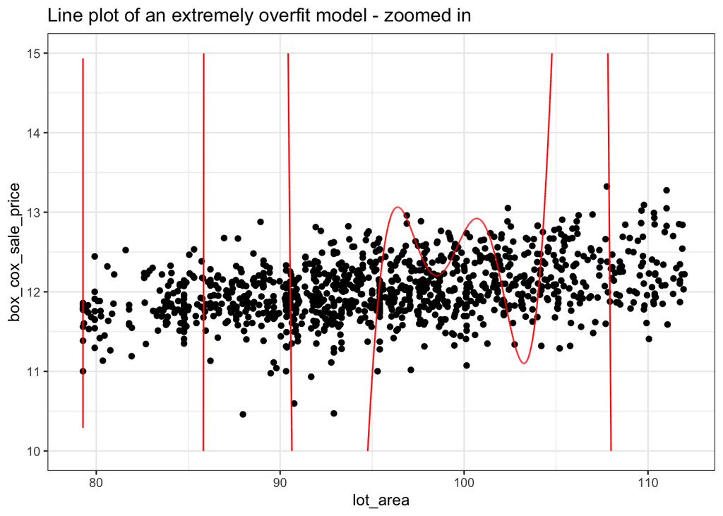

```r
ggplot(M_predict %>% dplyr::filter(degree == "10")) +
  aes(x = lot_area,y = box_cox_sale_price) +
  geom_point() +
  geom_line(data = M_polynomial,mapping = aes(x = lot_area,y = predict),color = "red") +
  xlim(79,112) +
  ylim(10,15) +
  theme_bw() +
  labs(
    title = "Line plot of an extremely overfit model - zoomed in"
  )
```

This model is totaly off the rails. Notice that none of our data points are anywhere near -1000 to -3000. The regression curve is nowhere near our data. Looking closer at the area where the curve is near the data, we can see that there is somewhat of a linear trend but the model isnt capturing it, instead its going up and down and off the rails.

As the polynomial degree increases, we notice the model fits the training data more closely, which results in a decreasing training MSE. However, the validation/test MSE starts to increase after a certain degree, indicating overfitting. The model is fitting noise present in the training data and doesn’t generalize well to the validation set.

# Bias-Variance Tradeoff

It’s pivotal to appreciate that the total prediction error is the summation of three distinct errors:

- **Bias**: This error emerges from the assumptions made by the model. A high bias implies the model is making strong assumptions about the form of the target function, potentially leading to underfitting.
- **Variance**: Represents the error arising due to the model’s sensitivity to minor fluctuations in the training data. A high variance suggests that the model may model the random noise in the training data, leading to overfitting.
- **Irreducible Error**: This is the inherent noise in the data. This error component is independent of the model and cannot be reduced by any model.

The equation encapsulating this relationship is:

$$\text{Total Error} = \text{Bias}^2 +
\text{Variance} + \text{Irreducible Error}$$

The bias-variance tradeoff is thus:

- Models with high bias tend to have low variance, leading to underfitting.
- Conversely, low bias models tend to have high variance, leading to overfitting.

The challenge is to strike a harmonious balance to minimize the total error.

## Example: Optimal Degree Selection

Let’s use cross-validation to estimate the best degree of a polynomial regression model. Notice that, up to machine accuracy, the training mean squared error decreases as the degree increases. But after a certain point the validation mean squared error gets worse and worse as the degree increases. Notice how the difference between the validation and training statistics gives us insight into over fitting. Models with degree less than optimal are under fit. Models with degree greater than optimal are over fit. All of this information will help us decide the optimal degree or the optimal bias variance.

Here we have 1 predictor variable and 1 target variable. We will use powers of the predictor variable to get the best model we can.

```r
knitr::opts_chunk$set(
  warning = FALSE,
  message = FALSE
)
set.seed(
  seed = 823
)
M <- M %>%
  dplyr::mutate(
    train_test = sample(x = 1:10,size = dplyr::n(),replace = TRUE)
  )
list_M <- split(
  x = M,
  f = M$train_test
)
M_mse <- expand.grid(
  degree = 1:20, ############################## degree up to 20
  train = names(list_M),
  newdata = names(list_M),
  stringsAsFactors = FALSE,
  mse = NA
) %>%
  dplyr::mutate(
    train_test = ifelse(train == newdata,"train","validation")
  )
for(j in 1:nrow(M_mse)) try({
  M_train <- list_M[[M_mse$train[j]]][,c("lot_area","box_cox_sale_price")]
  M_newdata <- list_M[[M_mse$newdata[j]]][,c("lot_area","box_cox_sale_price")]
  lm_0 <- lm(
    formula = box_cox_sale_price ~ poly(lot_area,M_mse$degree[j]),
    data = M_train
  )
  M_mse$mse[j] <- mean(
    x = (predict(
      object = lm_0,
      newdata = M_newdata
    ) - M_newdata$box_cox_sale_price)^2
  )
},silent = TRUE)
M_mse %>%
  dplyr::group_by(degree,train_test) %>%
  dplyr::summarise(mean_mse = mean(mse,na.rm = TRUE)) %>%
  dplyr::ungroup() %>%
  tidyr::spread(key = train_test,value = mean_mse) %>%
  dplyr::filter(!is.na(train)) %>%
  dplyr::mutate(
    difference = validation - train,
    min_train = ifelse(train == min(train,na.rm = TRUE),"min_train",""),
    min_validation = ifelse(validation == min(validation,na.rm = TRUE),"min_validation","")
  )
```

```
## # A tibble: 20 × 6
##    degree        train validation difference min_train   min_validation
##     <int>        <dbl>      <dbl>      <dbl> <chr>       <chr>
##  1      1        0.131   1.34e- 1   3.23e- 3 ""          ""
##  2      2        0.130   1.35e- 1   5.54e- 3 ""          ""
##  3      3        0.126   1.33e- 1   7.43e- 3 ""          ""
##  4      4        0.125   1.35e- 1   9.71e- 3 ""          ""
##  5      5        0.117   1.31e- 1   1.37e- 2 ""          "min_validation"
##  6      6        0.116   1.31e- 1   1.50e- 2 ""          ""
##  7      7        0.115   1.39e- 1   2.43e- 2 ""          ""
##  8      8        0.115   2.02e- 1   8.76e- 2 ""          ""
##  9      9        0.114   4.39e- 1   3.25e- 1 ""          ""
## 10     10        0.113   3.77e+ 0   3.66e+ 0 ""          ""
## 11     11        0.112   1.25e+ 1   1.24e+ 1 ""          ""
## 12     12        0.111   6.72e+ 0   6.61e+ 0 ""          ""
## 13     13        0.111   4.47e+ 2   4.47e+ 2 ""          ""
## 14     14        0.110   3.62e+ 3   3.62e+ 3 ""          ""
## 15     15        0.109   7.64e+ 3   7.64e+ 3 ""          ""
## 16     16        0.108   4.61e+ 5   4.61e+ 5 ""          ""
## 17     17        0.107   6.20e+ 6   6.20e+ 6 ""          ""
## 18     18        0.107   2.12e+ 7   2.12e+ 7 ""          ""
## 19     19        0.106   9.28e+ 8   9.28e+ 8 "min_train" ""
## 20     20 33280973.      5.57e+11   5.57e+11 ""          ""
```

By utilizing cross-validation, we can identify the polynomial degree that offers the lowest cross-validated RMSE. We see that training statistics decrease as degree increases (it increases at the end but it theoretically shouldnt, this is computer error). We see that degree 19 gives us a minimum training statistic however degree 5 gives us a minimum validation statistic. We see that the validation statistics decrease as degree increases before shooting back up after 5. If we were to use a polynomial regression model we would go with degree 5. Remember the larger the difference between validation and training statistics, the more prone we are to overfitting. The difference is quite small at degree 5 with e-2.

# Conclusion

Navigating the treacherous waters of model complexity and generalization is no small feat. Striking the right balance between overfitting and underfitting is critical to creating models that not only perform well on training data but also generalize effectively to unseen data. Through understanding and using tools like the bias-variance tradeoff, we can craft models that truly capture the underlying patterns of our data without getting swayed by its noise.

# Homework Problems

1. **Generalization Evaluation**: Using your own dataset, split it into a training and validation set. Build a simple linear regression model and evaluate its generalization capability (single predictor variable). Compare the performance metrics on both sets.
2. **Optimization**: Using cross-validation to estimate the optimal degree for a polynomial regression model.
3. **Multiple Linear Regression** Fit a multiple linear regression model with every predictor variable in your data set. Use feature engineering as needed to grossly over fit your model.
4. **LASSO Regression** Fit a LASSO regression model with every predictor variable in your multiple linear regression model. Compare the coefficients.
5. **Ridge Regression** Fit a Ridge regression model with every predictor variable in your multiple linear regression model. Compare the coefficients.